# Bayesian Chi Squared Procedures

Author

Alisa Krasilnikov, Harshini Karthikeyan

## References:

1. Doing Bayesian data analysis:
- Chapter 24 - Count Predicted Variables
- Exercise 24.3
2. STAT 415 Handouts
3. https://www.flutterbys.com.au/stats/tut/tut11.2b.html
4. Dataset: https://www.kaggle.com/datasets/kritirathi/indian-food-dataset-with
5. Log Reg Assumptions: https://www.bayesrulesbook.com/chapter-13#eq:log-model-ch13
6. https://jrnold.github.io/bayesian_notes/separtion.html#quasi-separation

## Data

```r
library(brms)
library(tidybayes)
library(dplyr)
library(broom)
library(tidyr)
library(ggplot2)
library(kableExtra)
```

Our dataset is the Indian food data set from Kaggle https://www.kaggle.com/datasets/kritirathi/indian-food-dataset-with. This is a set which pulls data from online Indian food recipes, and classifies them in various categories. We are particularly interested in whether there is a difference in flavor profile (spicy, sweet, and bitter) across diets (vegetarian and non-vegetarian).

```r
indfood <- read.csv(here::here("Ifood_new.csv"))
```

```r
indfood <- indfood |>
  filter(flavor_profile != "-1",
         flavor_profile != "sour") |> #There is only one sour dish in the dataset
  mutate(dum_diet = if_else(diet == "vegetarian", 1, 0))
```

```r
summary(indfood)
```

```
     name           ingredients            diet             prep_time
 Length:225         Length:225         Length:225         Min.   : -1.00
 Class :character   Class :character   Class :character   1st Qu.: 10.00
 Mode  :character   Mode  :character   Mode  :character   Median : 10.00
                                                          Mean   : 30.54
                                                          3rd Qu.: 20.00
                                                          Max.   :500.00
   cook_time      flavor_profile        course             state
 Min.   : -1.00   Length:225         Length:225         Length:225
 1st Qu.: 20.00   Class :character   Class :character   Class :character
 Median : 30.00   Mode  :character   Mode  :character   Mode  :character
 Mean   : 36.18
 3rd Qu.: 45.00
 Max.   :720.00
    region            img_url             dum_diet
 Length:225         Length:225         Min.   :0.0000
 Class :character   Class :character   1st Qu.:1.0000
 Mode  :character   Mode  :character   Median :1.0000
                                       Mean   :0.8889
                                       3rd Qu.:1.0000
                                       Max.   :1.0000
```

### Research Question:

**Is there a relationship between the flavor profile of Indian dishes and whether they are vegetarian or not?**

We will try to answer this question by modeling diet (vegetarian or non-vegetarian) as a function of flavor profile (sweet, spicy, or bitter), using Bayesian logistic regression.

### Weaknesses of the Data

There is complete separation of sweetness/bitterness and vegetarian, with all sweet or bitter foods in our data being vegetarian. Thus this dataset would be unable to be run with a frequentist approach, but choosing an adequate prior might allow for it to work with Bayesian statistics. Additionally, we dropped the flavor_profile sour as there is only one sour dish in the entire dataset.

```r
indfood |> group_by(diet) |> count(flavor_profile)
```

```
# A tibble: 4 × 3
# Groups:   diet [2]
  diet           flavor_profile     n
  <chr>          <chr>          <int>
1 non vegetarian spicy             25
2 vegetarian     bitter             4
3 vegetarian     spicy            108
4 vegetarian     sweet             88
```

## Choice of Likelihood and Model Assumptions

We use a Bayesian logistic regression model to investigate whether a dish’s flavor profile (sweet, spicy, or bitter) predicts whether it is vegetarian. The outcome variable, dum_diet, is binary: 1 if the dish is vegetarian and 0 otherwise. Given the binary nature of the response variable, we model the likelihood using a Bernoulli distribution with a logit link function, which is standard for binary outcome models.

Formally, the model assumes:

$dum\_diet_i$ ~ $Bernoulli(p_i)$ with $logit(p_i) = \beta_0 + \beta_1(sweet_i) + \beta_2(spicy_i)$

Here, bitter is the reference category for flavor profile (captured by the intercept, $\beta_0$. The predictors sweet and spicy are treated as dummy variables indicating the flavor profile of each dish. The log-odds of a dish being vegetarian are modeled as a linear function of its flavor profile.

This model relies on several assumptions:

- **Bernoulli likelihood:** Each dish’s vegetarian status is modeled as a Bernoulli trial with probability pi. As each dish is either vegetarian or non-vegetarian(no in-betweens), modeling them using a Bernoulli likelihood is appropriate.
- **Independent Observations:** Each dish’s flavor and vegetarian status are independent of others. This assumption is valid, as we can assume each dish as an individual unit. If several subsets of foods were dependent on being served with each other(often paired), this might be invalid, but we would say we’re fine as it is.
- **Linearity:** The log-odds of being vegetarian are linearly related to the dummy-coded flavor indicators. This assumption is met as we have mutually exclusive categorical data(no food has more than one flavor profile). Thus, we assume that each flavor category has a fixed additive effect on the log-odds of being vegetarian, which is appropriate for categorical predictors.
- **No Complete Separation:** Ideally, no predictor or combination of predictors would perfectly predict the outcome. We do not meet this assumption.

In the dataset, all sweet and bitter dishes are vegetarian, resulting in complete separation for those categories. This poses a challenge for frequentist logistic regression, which can yield infinite or undefined parameter estimates. However, the Bayesian approach can still yield valid inference by incorporating informative priors, which effectively regularize the estimates and prevent the model from overfitting to the separation.

## Bayesian model

### Choosing Priors

We’ll assume the betas and sigma are independent. We believe that if a dish is sweet rather than bitter, then it will most likely be a vegetarian dish, since we couldn’t think of many examples of desserts which were not vegetarian. Therefore, we specify an informative prior for the coefficient of the sweet flavor profile that reflects our belief that it increases the probability a dish is vegetarian (i.e., that it pushes the log-odds in a positive direction):

$\beta_{sweet}$ ~ N(0.75, 0.2)

This prior centers the log-odds increase at 0.75, while still allowing moderate uncertainty. For the other coefficients, we do not have strong prior opinions, and we allow brms to apply its default weakly informative priors.

**Prior predictive dist for sweet dish**

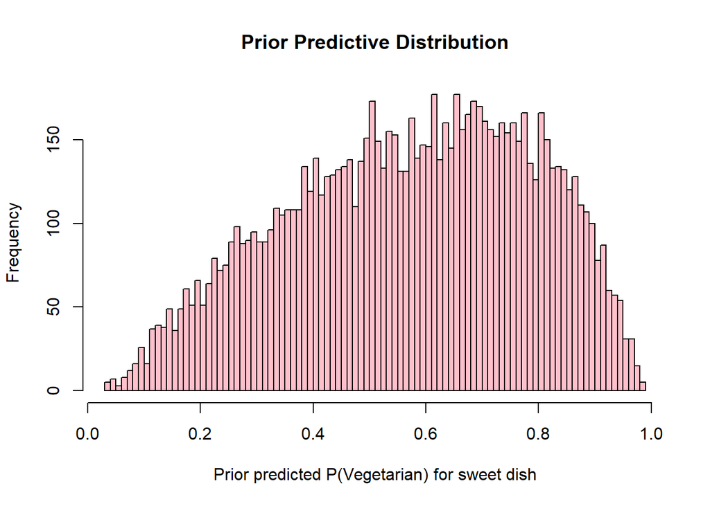

```r
n_rep = 10000

beta0 <- rnorm(n_rep, 0, 1)
beta_sweet <- rnorm(n_rep, 0.75, 0.2)

sweet <- sample(c(0, 1), n_rep, replace = TRUE)
log_odds <- beta0 + beta_sweet * sweet

p <- 1 / (1 + exp(-log_odds))

y_sim <- rbinom(n_rep, size = 1, prob = p)

hist(p,
     xlab = "Prior predicted P(Vegetarian) for sweet dish",
     breaks = 100,
     col = "pink",
     main = "Prior Predictive Distribution")
```

This isn’t exactly what we want. The range is a little bit too big, but we like where it’s centered. Let’s adjust it a little bit so the effect of sweetness is a little bit stronger.

$\beta_{sweet}$ ~ N(1.75, 0.5)

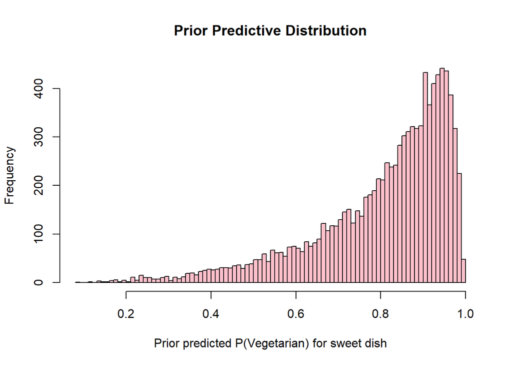

```r
beta_0 <- rnorm(n_rep, 0, 1)
beta_sweet <- rnorm(n_rep, 1.75, 0.5)

log_odds <- beta0 + beta_sweet

p <- 1 / (1 + exp(-log_odds))

y_sim <- rbinom(n_rep, size = 1, prob = p)

hist(p,
     xlab = "Prior predicted P(Vegetarian) for sweet dish",
     breaks = 100,
     col = "pink",
     main = "Prior Predictive Distribution")
```

This looks a little better!

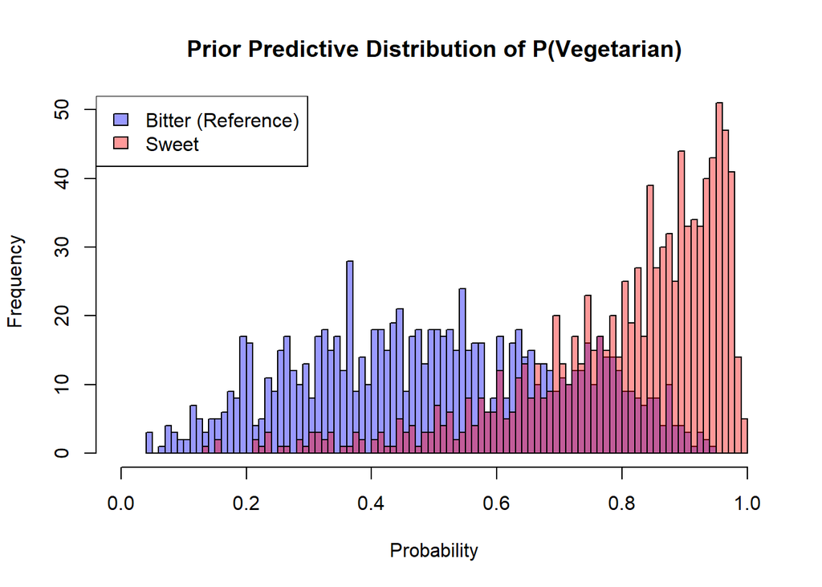

```r
n_rep = 1000

# x is binary: 0 (not sweet), 1 (sweet)
x <- sample(c(0, 1), n_rep, replace = TRUE)

# Priors for coefficients
beta0 <- rnorm(n_rep, 0, 1)           # intercept
beta1 <- rnorm(n_rep, 1.75, 0.5)      # effect for sweet = 1


# Compute probabilities for x = 0 and x = 1
p0 <- plogis(beta0 + beta1 * 0)  # not sweet (bitter)
p1 <- plogis(beta0 + beta1 * 1)  # sweet

# Plot histograms
hist(p0, breaks=100, col=rgb(0,0,1,0.4), xlim=c(0,1), ylim = c(0, 50),
     main="Prior Predictive Distribution of P(Vegetarian)",
     xlab="Probability", ylab="Frequency")
hist(p1, breaks=100, col=rgb(1,0,0,0.4), add=TRUE)
legend("topleft", legend=c("Bitter (Reference)", "Sweet"),
       fill=c(rgb(0,0,1,0.4), rgb(1,0,0,0.4)))
```

## Posterior Inference

### Fitting with brms

```r
set.seed(123)

fit <- brm(
  data = indfood,
  family = bernoulli(link = "logit"),
  dum_diet ~ 1 + flavor_profile,
  prior = c(
    prior(normal(1.75, 0.5), class = "b", coef = "flavor_profilesweet")
    # No need to set priors for other coefficients, since we're happy with defaults
  ),
  iter = 4000,
  warmup = 1000,
  control = list(max_treedepth = 15),
  chains = 4,
  refresh = 0
)
```

[output not shown]

```
Trying to compile a simple C file
```

[output not shown]

[output not shown]

```r
summary(fit)
```

```
 Family: bernoulli
  Links: mu = logit
Formula: dum_diet ~ 1 + flavor_profile
   Data: indfood (Number of observations: 225)
  Draws: 4 chains, each with iter = 4000; warmup = 1000; thin = 1;
         total post-warmup draws = 12000

Regression Coefficients:
                    Estimate Est.Error l-95% CI u-95% CI Rhat Bulk_ESS Tail_ESS
Intercept               9.71      8.00     2.47    32.69 1.01     1250     1000
flavor_profilespicy    -8.24      8.00   -31.12    -0.96 1.01     1252      998
flavor_profilesweet     1.75      0.50     0.75     2.74 1.00     3214     3283

Draws were sampled using sampling(NUTS). For each parameter, Bulk_ESS
and Tail_ESS are effective sample size measures, and Rhat is the potential
scale reduction factor on split chains (at convergence, Rhat = 1).
```

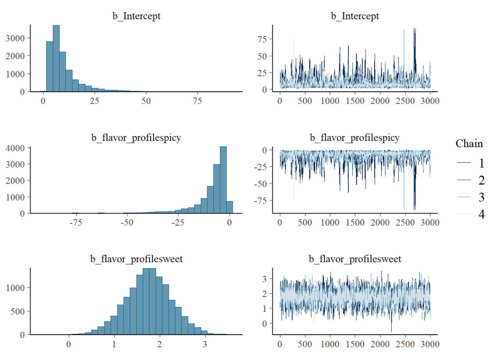

```r
plot(fit)
```

### Interpreting Coefficients

The intercept represents the log-odds of a dish being vegetarian when the flavor is bitter. All other coefficients are interpreted relative to this baseline.

The posterior intercept is 9.68, indicating that the odds of a `bitter` dish being vegetarian are approximately 15,994.5 to 1 (exp(9.68)). That is, bitter dishes are extremely likely to be vegetarian. Translated to probability, the probability of a dish being vegetarian given it is bitter is about 99% ($\frac{1}{1+e^{-9.68}} = 0.99$).

The posterior mean for `sweet` is 1.74. So, based on our posterior, we are most confident that the odds of sweet dishes being vegetarian are approximately ~470% ($(e^{1.74} - 1)*100$%) higher than those of bitter dishes.

The posterior mean for `spicy` is -8.21. So, based on our posterior, we are most confident that the odds of dishes with spicy flavor being vegetarian are about ~99.97% ($(1 - e^{-8.21})*100$%) lower than those of bitter dishes.

### 95% Credible Intervals

```r
post <- as_draws_df(fit)

theta_bitter <- plogis(post$b_Intercept)

#plogis basically just converts to probability
theta_sweet  <- plogis(post$b_Intercept + post$`b_flavor_profilesweet`)
theta_spicy  <- plogis(post$b_Intercept + post$`b_flavor_profilespicy`)

thetas <- tibble(
  bitter = theta_bitter,
  sweet  = theta_sweet,
  spicy  = theta_spicy
)


thetas_summary <- thetas |>
  pivot_longer(cols = everything(), names_to = "flavor_profile", values_to = "theta") |>
  group_by(flavor_profile) |>
  summarise(
    mean_theta = mean(theta),
    .lower = quantile(theta, 0.025),
    .upper = quantile(theta, 0.975)
  )

thetas_summary
```

```
# A tibble: 3 × 4
  flavor_profile mean_theta .lower .upper
  <chr>               <dbl>  <dbl>  <dbl>
1 bitter              0.990  0.922  1.00
2 spicy               0.811  0.739  0.873
3 sweet               0.998  0.987  1.00
```

**Spicy: (0.74, 0.872)**

Based on the posterior distribution, there is a 95% probability that the true probability of a dish being vegetarian, given it is spicy, lies between 74% and 87.2%. As our data has some of the spicy dishes as non-vegetarian this feels more accurate.

**Sweet: (0.987, 1.000)**

Based on the posterior distribution, there is a 95% probability that the true probability of a dish being vegetarian, given it is sweet, lies between 98.8% and 100%. This supports our prior belief that sweet foods are almost always vegetarian.

## Posterior Prediction

```r
posterior <- fit |>
  spread_draws(b_Intercept, b_flavor_profilesweet, b_flavor_profilespicy)

posterior_flavors <- posterior |>
  mutate(
    eta_bitter = b_Intercept + 0 * b_flavor_profilesweet + 0 * b_flavor_profilespicy,
    p_bitter   = 1 / (1 + exp(-eta_bitter)),
    y_bitter   = rbinom(n(), 1, p_bitter),

    eta_sweet = b_Intercept + 1 * b_flavor_profilesweet + 0 * b_flavor_profilespicy,
    p_sweet   = 1 / (1 + exp(-eta_sweet)),
    y_sweet   = rbinom(n(), 1, p_sweet),

    eta_spicy = b_Intercept + 0 * b_flavor_profilesweet + 1 * b_flavor_profilespicy,
    p_spicy   = 1 / (1 + exp(-eta_spicy)),
    y_spicy   = rbinom(n(), 1, p_spicy)
  )

#first few rows
posterior_flavors |>
  select(p_bitter, y_bitter, p_sweet, y_sweet, p_spicy, y_spicy) |>
  head(10) |>
  kbl(digits = 3) |>
  kable_styling()
```

| p_bitter | y_bitter | p_sweet | y_sweet | p_spicy | y_spicy |
| --- | --- | --- | --- | --- | --- |
| 1.000 | 1 | 1.000 | 1 | 0.857 | 1 |
| 1.000 | 1 | 1.000 | 1 | 0.835 | 1 |
| 1.000 | 1 | 1.000 | 1 | 0.818 | 1 |
| 1.000 | 1 | 1.000 | 1 | 0.818 | 1 |
| 1.000 | 1 | 1.000 | 1 | 0.799 | 0 |
| 1.000 | 1 | 1.000 | 1 | 0.850 | 1 |
| 0.998 | 1 | 0.999 | 1 | 0.848 | 1 |
| 1.000 | 1 | 1.000 | 1 | 0.794 | 1 |
| 1.000 | 1 | 1.000 | 1 | 0.788 | 1 |
| 0.972 | 1 | 0.997 | 1 | 0.816 | 1 |

```r
#longer
posterior_long <- posterior_flavors |>
  select(y_bitter, y_sweet, y_spicy) |>
  pivot_longer(cols = everything(),
               names_to = "flavor_profile",
               values_to = "y_sim") |>
  mutate(flavor_profile = case_when(
    flavor_profile == "y_bitter" ~ "Bitter",
    flavor_profile == "y_sweet" ~ "Sweet",
    flavor_profile == "y_spicy" ~ "Spicy"
  ))

posterior_long |>
  head(10) |>
  kbl(digits = 3) |>
  kable_styling()
```

| flavor_profile | y_sim |
| --- | --- |
| Bitter | 1 |
| Sweet | 1 |
| Spicy | 1 |
| Bitter | 1 |
| Sweet | 1 |
| Spicy | 1 |
| Bitter | 1 |
| Sweet | 1 |
| Spicy | 1 |
| Bitter | 1 |

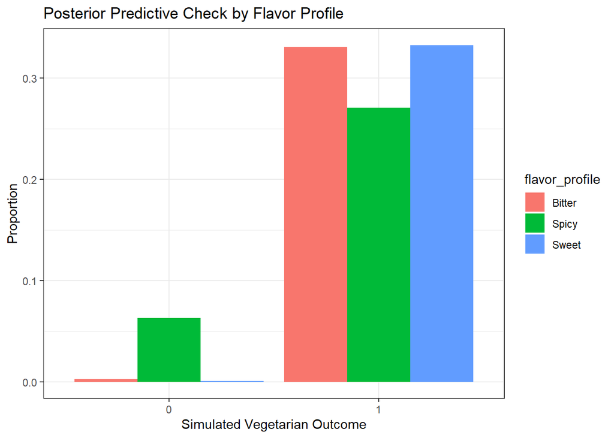

```r
ggplot(posterior_long, aes(x = factor(y_sim), fill = flavor_profile)) +
  geom_bar(position = "dodge", aes(y = (..count..) / sum(..count..))) +
  labs(x = "Simulated Vegetarian Outcome",
       y = "Proportion",
       title = "Posterior Predictive Check by Flavor Profile") +
  theme_bw()
```

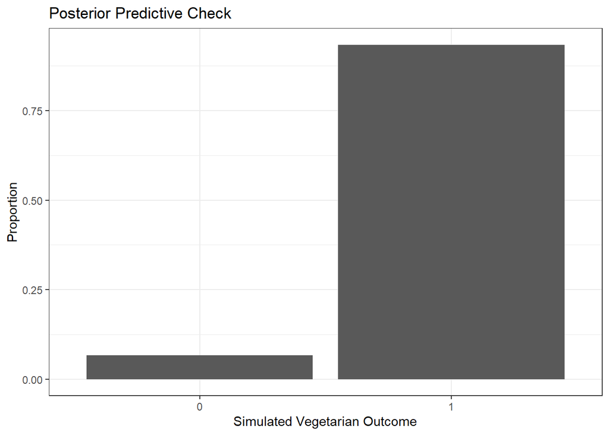

```r
#overall
ggplot(posterior_long, aes(x = factor(y_sim))) +
  geom_bar(position = "dodge", aes(y = (..count..) / sum(..count..))) +
  labs(x = "Simulated Vegetarian Outcome",
       y = "Proportion",
       title = "Posterior Predictive Check") +
  theme_bw()
```

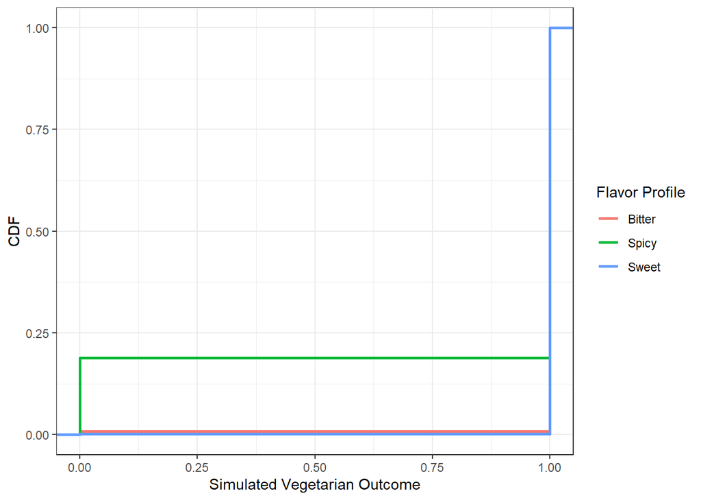

```r
# CDF plot for each flavor
ggplot(posterior_long, aes(x = y_sim, color = flavor_profile)) +
  stat_ecdf(linewidth = 1) +
  labs(x = "Simulated Vegetarian Outcome", y = "CDF", color = "Flavor Profile") +
  theme_bw()
```

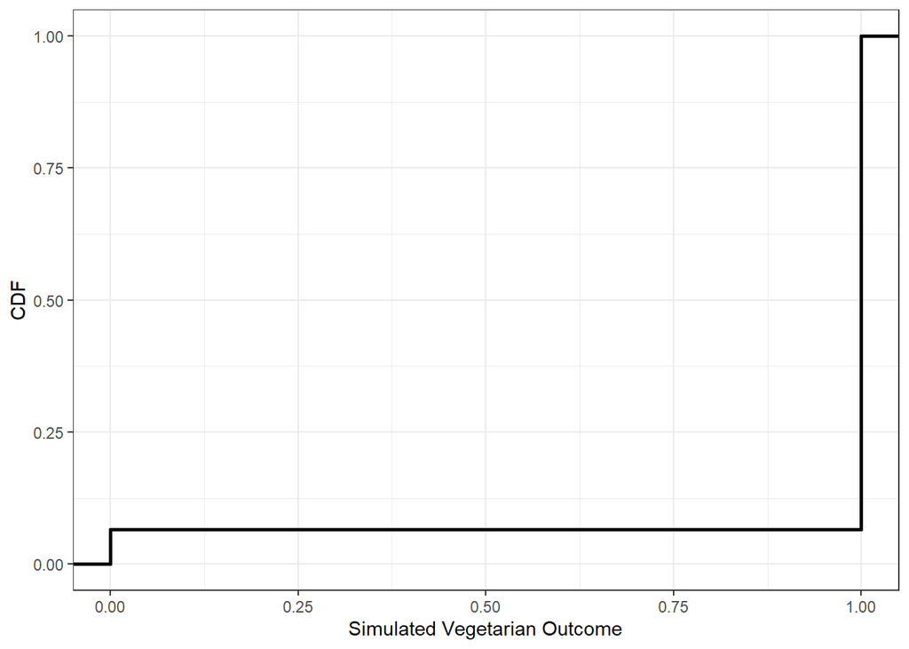

```r
#overall
ggplot(posterior_long, aes(x = y_sim)) +
  stat_ecdf(linewidth = 1) +
  labs(x = "Simulated Vegetarian Outcome", y = "CDF") +
  theme_bw()
```

```r
# Posterior predictive 95% interval for each flavor
posterior_long |>
  group_by(flavor_profile) |>
  summarise(
    mean = mean(y_sim),
    lower = quantile(y_sim, 0.025),
    upper = quantile(y_sim, 0.975)
  )
```

```
# A tibble: 3 × 4
  flavor_profile  mean lower upper
  <chr>          <dbl> <dbl> <dbl>
1 Bitter         0.992     1     1
2 Spicy          0.812     0     1
3 Sweet          0.998     1     1
```

- **Bitter**: The model predicts that bitter dishes are vegetarian 99% of the time, and the 95% posterior predictive interval is (1, 1). This suggests extremely high confidence that bitter dishes are vegetarian. It aligns with our dataset where all bitter dishes are vegetarian.
- **Sweet**: The model predicts that sweet dishes are vegetarian 99.8% of the time, with a 95% predictive interval of (1, 1). It aligns with our dataset where all sweet dishes are vegetarian.
- **Spicy**: The predicted probability of a spicy dish being vegetarian is around 81%, and the interval (0, 1) reflects that uncertainty. It aligns with our dataset where all spicy dishes are vegetarian OR non-vegetarian.

## Posterior Predictive Checking

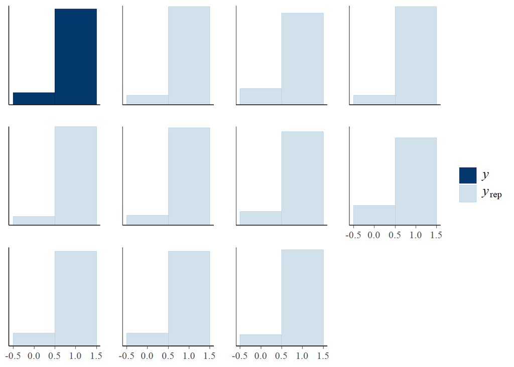

```r
pp_check(fit, type = "hist", ndraw = 10, bins =2)
```

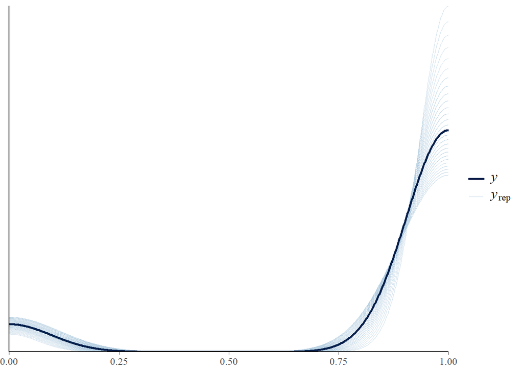

```r
pp_check(fit, ndraw = 100)
```

The overall plots for posterior predictive, when not separated by flavor pass the posterior predictive check. However, when we plotted the posterior predictive by flavor, we could see the issue. The histogram distribution is closest to spicy, thus sweet and bitter fail the posterior predictive check. Further, only the CDF for spicy looks similar to what we would expect to see for the posterior predictive. Given the fact that our data has quasi-complete separation, with all sweet or bitter foods being vegetarian, this makes sense.

## Sensitivity Analysis

Let’s change our prior for sweetness and see how it affects the model. First, let’s let brms choose the prior.

```r
set.seed(123)

fit <- brm(
  data = indfood,
  family = bernoulli(link = "logit"),
  dum_diet ~ 1 + flavor_profile,
  iter = 6000,
  warmup = 1000,
  control = list(max_treedepth = 15),
  chains = 4,
  refresh = 0
)
```

[output not shown]

```
Trying to compile a simple C file
```

[output not shown]

[output not shown]

```r
summary(fit)
```

```
 Family: bernoulli
  Links: mu = logit
Formula: dum_diet ~ 1 + flavor_profile
   Data: indfood (Number of observations: 225)
  Draws: 4 chains, each with iter = 6000; warmup = 1000; thin = 1;
         total post-warmup draws = 20000

Regression Coefficients:
                    Estimate Est.Error l-95% CI u-95% CI Rhat Bulk_ESS Tail_ESS
Intercept             286.29    591.13     5.59  1600.16 1.01      547      614
flavor_profilespicy  -284.82    591.13 -1598.74    -4.09 1.01      547      614
flavor_profilesweet  -269.10    581.34 -1562.74     8.39 1.01      599      613

Draws were sampled using sampling(NUTS). For each parameter, Bulk_ESS
and Tail_ESS are effective sample size measures, and Rhat is the potential
scale reduction factor on split chains (at convergence, Rhat = 1).
```

Whoa, those estimates look pretty wild! Without any sort of guidance, the model seems to be struggling with the quasi-complete separation within the data. All of the values are quite large, with very large standard errors.

Let’s try giving it a very tight prior for sweetness.

```r
set.seed(123)

fit <- brm(
  data = indfood,
  family = bernoulli(link = "logit"),
  dum_diet ~ 1 + flavor_profile,
  prior = c(
    prior(normal(5, 0.001), class = "b", coef = "flavor_profilesweet")
  ),
  iter = 4000,
  warmup = 1000,
  control = list(max_treedepth = 15),
  chains = 4,
  refresh = 0
)
```

[output not shown]

```
Trying to compile a simple C file
```

[output not shown]

[output not shown]

```r
summary(fit)
```

```
 Family: bernoulli
  Links: mu = logit
Formula: dum_diet ~ 1 + flavor_profile
   Data: indfood (Number of observations: 225)
  Draws: 4 chains, each with iter = 4000; warmup = 1000; thin = 1;
         total post-warmup draws = 12000

Regression Coefficients:
                    Estimate Est.Error l-95% CI u-95% CI Rhat Bulk_ESS Tail_ESS
Intercept               9.23     10.38     1.00    35.77 1.01      731      668
flavor_profilespicy    -7.77     10.39   -34.23     0.49 1.00      732      659
flavor_profilesweet     5.00      0.00     5.00     5.00 1.00     5684     4938

Draws were sampled using sampling(NUTS). For each parameter, Bulk_ESS
and Tail_ESS are effective sample size measures, and Rhat is the potential
scale reduction factor on split chains (at convergence, Rhat = 1).
```

The posterior estimates for intercept and spiciness are not incredibly different from what they were before, though a bit more uncertain, than when our prior was a little bit less intense. However, it appears as though the posterior estimate for sweetness is identical to our prior.

Let’s try a prior that uses a prior for sweetness that’s in the wrong direction.

```r
set.seed(123)

fit <- brm(
  data = indfood,
  family = bernoulli(link = "logit"),
  dum_diet ~ 1 + flavor_profile,
  prior = c(
    prior(normal(-1.75, 0.5), class = "b", coef = "flavor_profilesweet")
  ),
  iter = 4000,
  warmup = 1000,
  control = list(max_treedepth = 15),
  chains = 4,
  refresh = 0
)
```

[output not shown]

```
Trying to compile a simple C file
```

[output not shown]

[output not shown]

```r
summary(fit)
```

```
 Family: bernoulli
  Links: mu = logit
Formula: dum_diet ~ 1 + flavor_profile
   Data: indfood (Number of observations: 225)
  Draws: 4 chains, each with iter = 4000; warmup = 1000; thin = 1;
         total post-warmup draws = 12000

Regression Coefficients:
                    Estimate Est.Error l-95% CI u-95% CI Rhat Bulk_ESS Tail_ESS
Intercept              12.95      8.37     5.70    34.03 1.00     1136      971
flavor_profilespicy   -11.49      8.37   -32.67    -4.21 1.00     1134      941
flavor_profilesweet    -1.75      0.51    -2.75    -0.76 1.00     3248     3605

Draws were sampled using sampling(NUTS). For each parameter, Bulk_ESS
and Tail_ESS are effective sample size measures, and Rhat is the potential
scale reduction factor on split chains (at convergence, Rhat = 1).
```

The posterior for sweetness is, once again, almost identical to the prior that we put in.

This analysis indicates that our model really is sensitive to the prior that we put in. This is most definitely due to the fact that we have quasi-complete separation within our data. When no prior is specified (or rather, when we input the default priors), the model returns very large estimates and standard errors. This is a symptom of quasi-complete separation, where the likelihood is flat and the posterior is poorly identified. When a very tight prior (Normal(5, 0.001)) is imposed sweetness, the posterior exactly matches the prior. This shows the data doesn’t override the prior at all, meaning the likelihood contains almost no information about that coefficient (because all sweet dishes are vegetarian). When a strongly incorrect prior is imposed (Normal(-1.75, 0.5)), the posterior again conforms tightly to the prior. This further confirms that the data has no signal to counterbalance or correct the prior (quasi-separation behavior).

## Frequentist Approach:

### Chi-Squared Test

```r
# not sure we should do this but maybe?
table(indfood$flavor_profile, indfood$dum_diet) |> chisq.test()
```

```
Warning in chisq.test(table(indfood$flavor_profile, indfood$dum_diet)):
Chi-squared approximation may be incorrect
```

```
    Pearson's Chi-squared test

data:  table(indfood$flavor_profile, indfood$dum_diet)
X-squared = 19.455, df = 2, p-value = 5.962e-05
```

### Linear Model

We fit a linear model, specifically a generalized linear model (glm) instead of a linear model(lm) because our variables are not continuous and are instead categorical.

```r
glm(dum_diet ~ flavor_profile, data = indfood, family = "binomial")
```

```
Call:  glm(formula = dum_diet ~ flavor_profile, family = "binomial",
    data = indfood)

Coefficients:
        (Intercept)  flavor_profilespicy  flavor_profilesweet
          1.957e+01           -1.810e+01           -2.756e-10

Degrees of Freedom: 224 Total (i.e. Null);  222 Residual
Null Deviance:      157
Residual Deviance: 128.5    AIC: 134.5
```

The intercept corresponds to the log-odds of a bitter dish being vegetarian, which is very high (about 19.57 on the log-odds scale), indicating that bitter dishes are almost always vegetarian. The coefficient for spicy flavor is strongly negative (-18.10), reflecting that spicy dishes are much less likely to be vegetarian compared to bitter dishes. The coefficient for sweet flavor is essentially zero, as most sweet dishes in the data are vegetarian. The extreme size of some of our coefficients confirms what we would expect with the quasi-complete separation of 0.

## Conclusions

Overall, our analysis shows there is a clear association between flavor profile and vegetarian status, with bitter and sweet dishes almost always vegetarian and spicy dishes showing more variation. Due to quasi-complete separation, the model’s estimates for bitter and sweet are extreme and highly influenced by the prior.